# Gas Cost Estimator: comparison of obtained estimates, alternative gas cost schedule

Parametrization. The comma separeted list of csv files with precomputed estimated costs for evm clients estimate_files=estimated_cost_besu_create.csv,estimated_cost_besu_full.csv,estimated_cost_besu_mem.csv,estimated_cost_besu_precompiles.csv,estimated_cost_besu_stop.csv,estimated_cost_besu_t.csv,estimated_cost_erigon_create.csv,estimated_cost_erigon_full.csv,estimated_cost_erigon_mem.csv,estimated_cost_erigon_precompiles.csv,estimated_cost_erigon_stop.csv,estimated_cost_erigon_t.csv,estimated_cost_ethereumjs_create.csv,estimated_cost_ethereumjs_full.csv,estimated_cost_ethereumjs_mem.csv,estimated_cost_ethereumjs_stop.csv,estimated_cost_ethereumjs_t.csv,estimated_cost_evmone_create.csv,estimated_cost_evmone_full.csv,estimated_cost_evmone_mem.csv,estimated_cost_evmone_precompiles.csv,estimated_cost_evmone_t.csv,estimated_cost_geth_create.csv,estimated_cost_geth_full.csv,estimated_cost_geth_mem.csv,estimated_cost_geth_precompiles.csv,estimated_cost_geth_stop.csv,estimated_cost_geth_t.csv,estimated_cost_nethermind_create.csv,estimated_cost_nethermind_full.csv,estimated_cost_nethermind_mem.csv,estimated_cost_nethermind_precompiles.csv,estimated_cost_nethermind_t.csv,estimated_cost_revm_create.csv,estimated_cost_revm_full.csv,estimated_cost_revm_mem.csv,estimated_cost_revm_stop.csv,estimated_cost_revm_t.csv, the file with the reference gas cost table and groups configuration current_gas_cost=current_gas_cost.csv, used metric code metric=l1, should the details be included in the report details=FALSE.

Plot the scaled gas cost schedules.

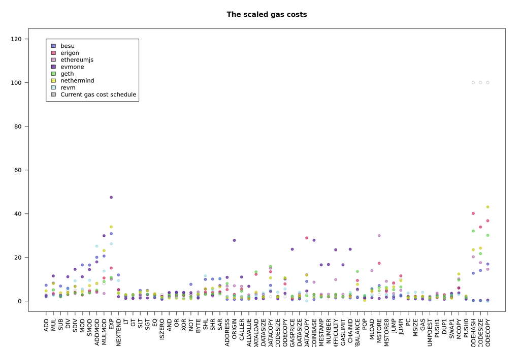

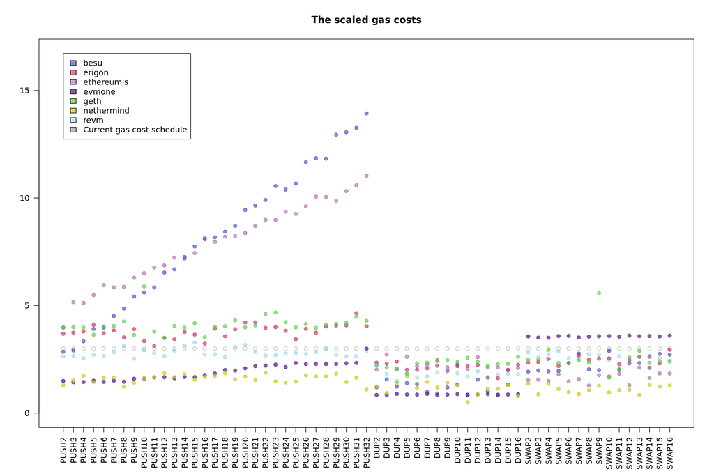

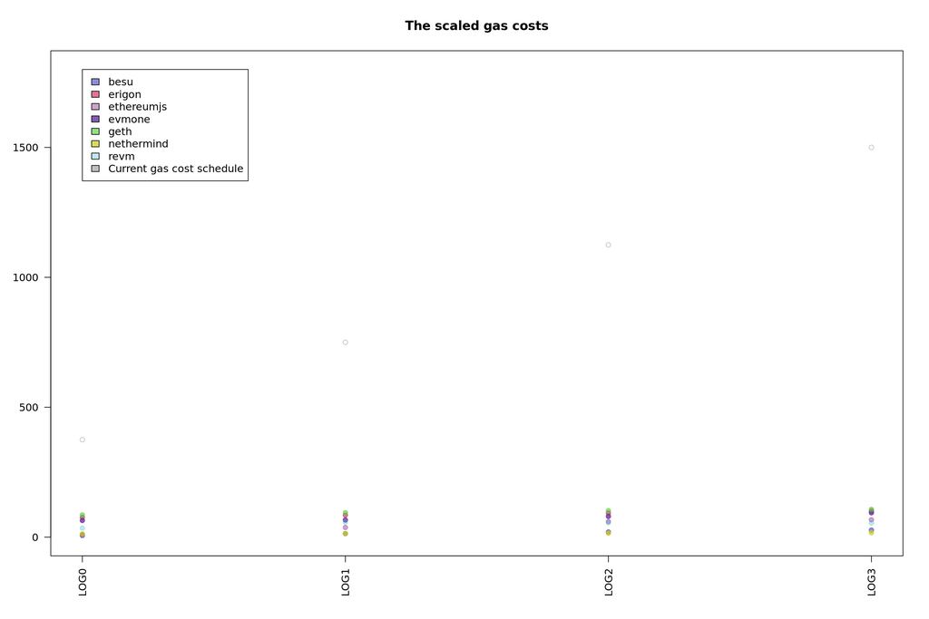

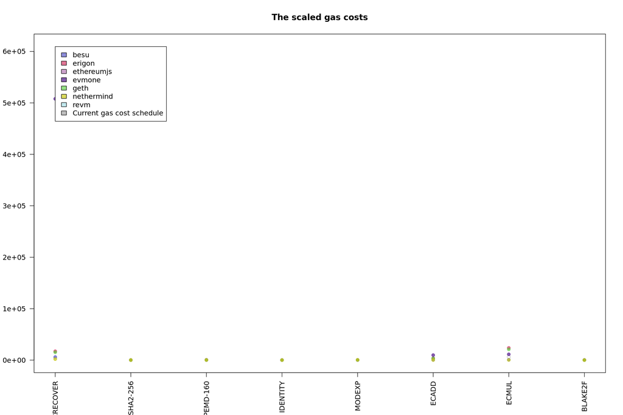

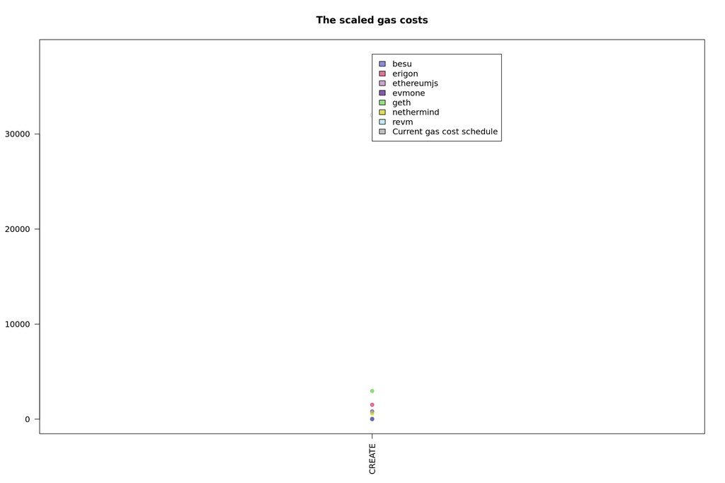

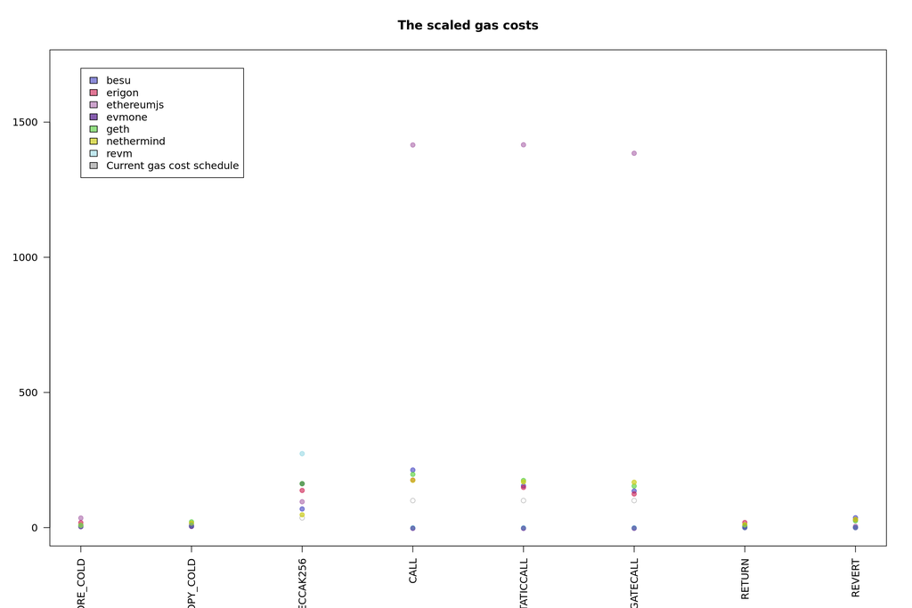

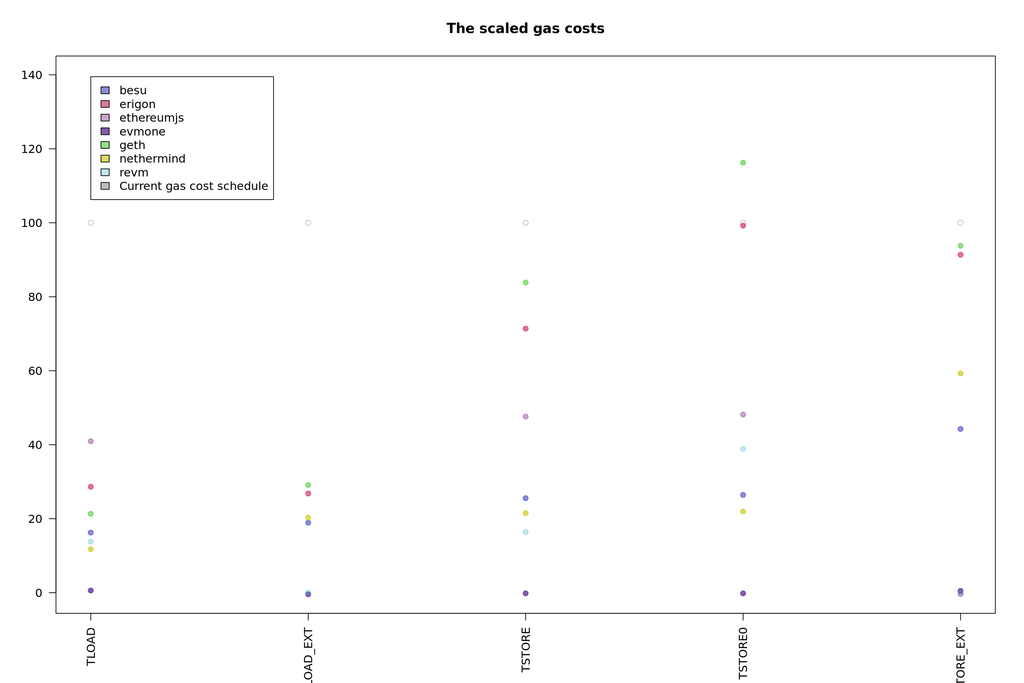

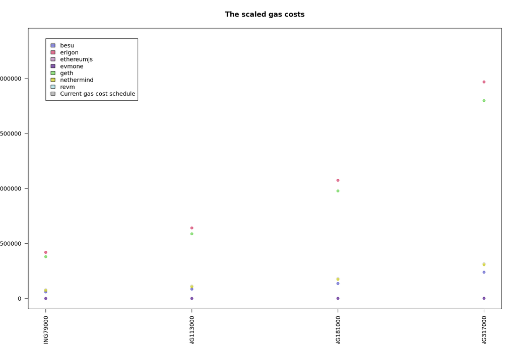

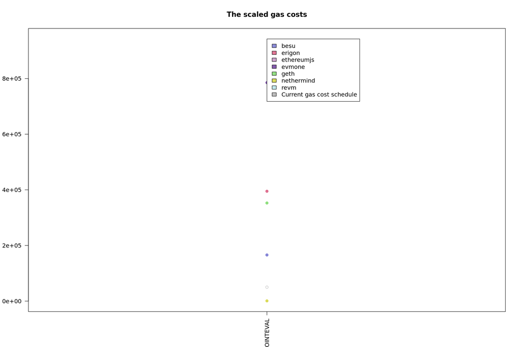

```r
for (g in 0:max_groups) {
  groups_opcode <- current_gas_cost[which(current_gas_cost$groups == g), "opcode"]
  if (length(groups_opcode) == 0) {
    next
  }
  grups_gas_schedule_comparison <- gas_schedule_comparison[which(gas_schedule_comparison$opcode %in% groups_opcode), ]
  if (nrow(grups_gas_schedule_comparison) == 0) {
    next
  }
  maximum_gas_cost = max(grups_gas_schedule_comparison[, c(all_envs_cols, "constant_current_gas")], na.rm=TRUE)
  plot(grups_gas_schedule_comparison$constant_current_gas, col='grey', xaxt='n', ylim=c(0,maximum_gas_cost * 1.2), xlab="", ylab="", las=2)
  axis(1, at=1:nrow(grups_gas_schedule_comparison), labels=grups_gas_schedule_comparison$opcode, las=2)
  for (i in 1:length(all_envs)) {
    points(grups_gas_schedule_comparison[, paste0(all_envs[i], "_gas")], col=env_colors[i], bg=env_colors[i], xaxt='n', pch=21)
  }
  title(main="The scaled gas costs")
  legend(1, maximum_gas_cost * 1.2, c(all_envs, "Current gas cost schedule"), fill=c(env_colors[1:length(all_envs)], 'grey'), cex=1)
}
```

Calculate and plot the alternative gas cost schedule. The calculated values are:

```r
gas_schedule_comparison[, c('opcode', 'constant_current_gas', 'alternative_gas', 'alternative_gas_stderr', 'alternative_gas_rel_diff', 'alternative_gas_rel_stderr')]
```

```
##              opcode constant_current_gas alternative_gas alternative_gas_stderr
## 1               ADD                    3    2.227048e+00           4.451017e+00
## 2               MUL                    5    5.197094e+00           2.653711e+00
## 3               SUB                    3    2.543919e+00           9.961149e-01
## 4               DIV                    5    4.055622e+00           1.796579e+00
## 5              SDIV                    5    6.687413e+00           2.758657e+00
## 6               MOD                    5    4.462124e+00           3.518134e+00
## 7              SMOD                    5    7.089460e+00           4.038509e+00
## 8            ADDMOD                    8    8.151363e+00           7.090281e+00
## 9            MULMOD                    8    1.373004e+01           7.236385e+00
## 10              EXP                   10    2.622920e+01           1.090240e+01
## 11       SIGNEXTEND                    5    5.252901e+00           2.471626e+00
## 12               LT                    3    2.281353e+00           5.063179e-01
## 13               GT                    3    2.643599e+00           4.981957e-01
## 14              SLT                    3    2.959906e+00           9.238426e-01
```

[output cut: 295 more lines]

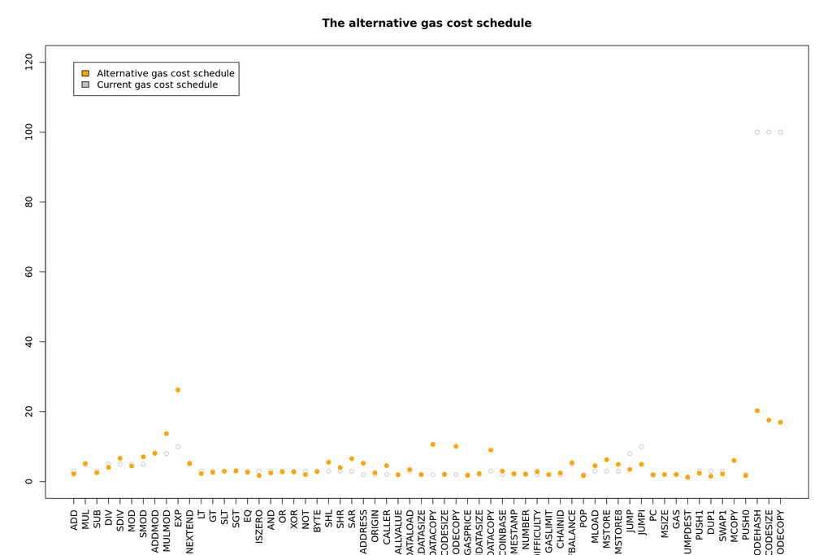

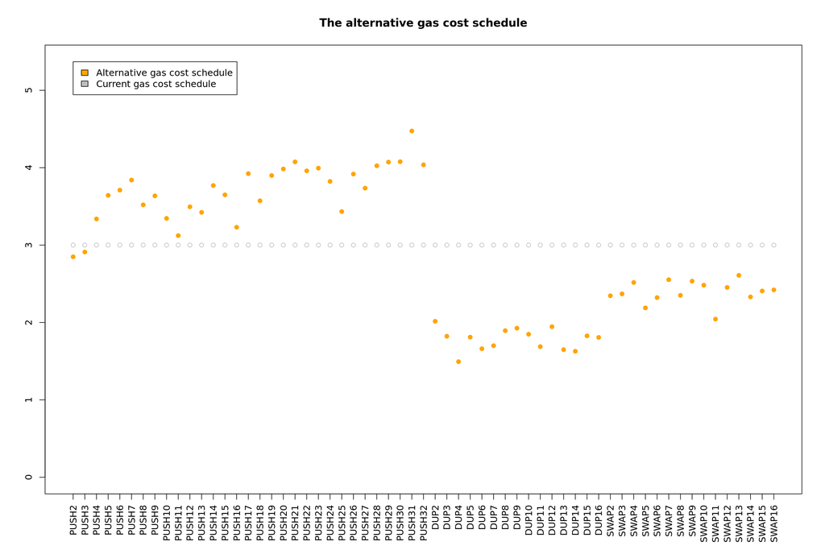

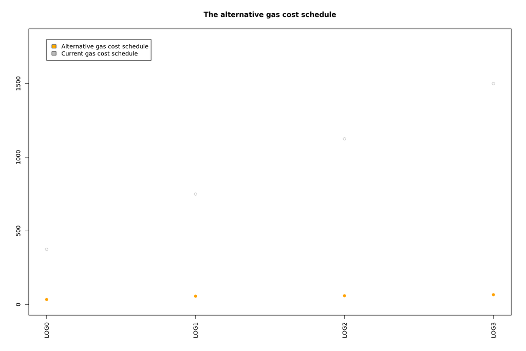

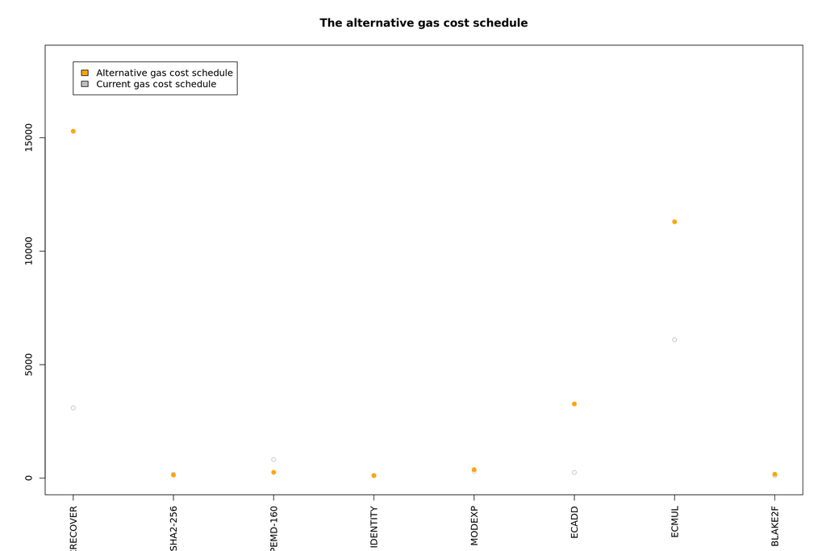

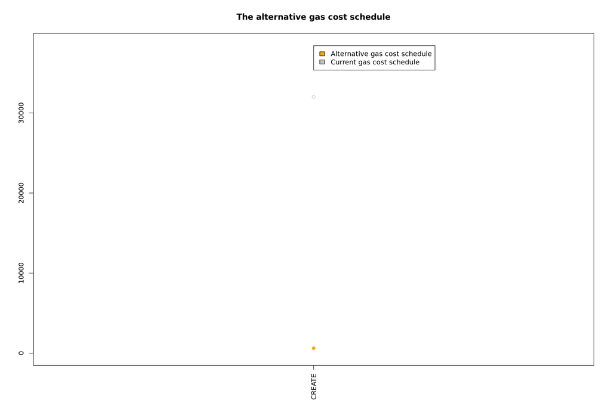

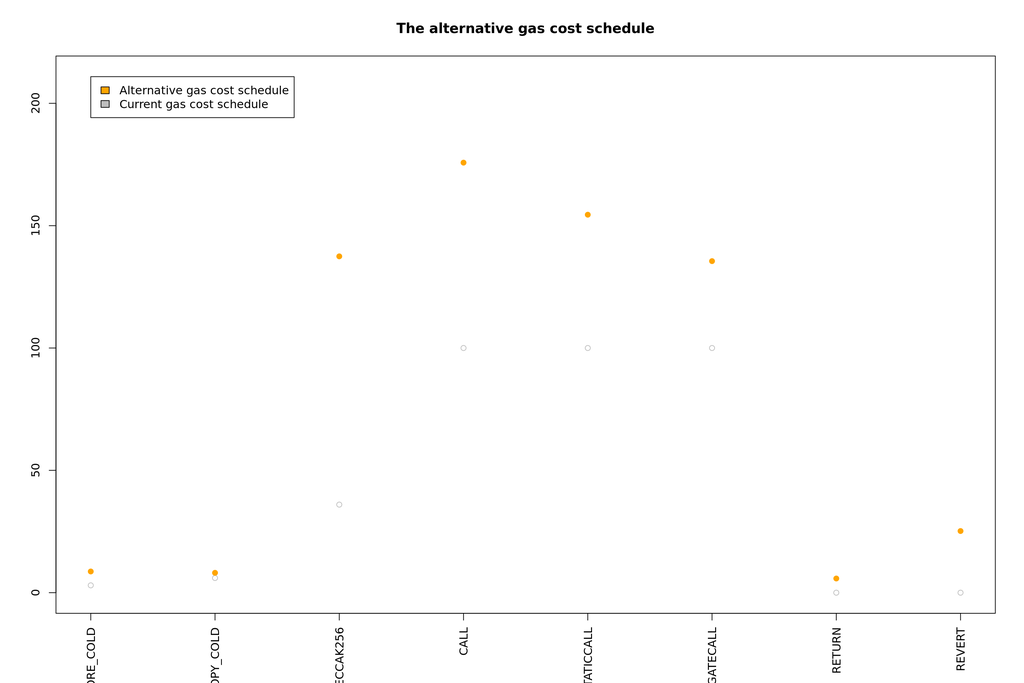

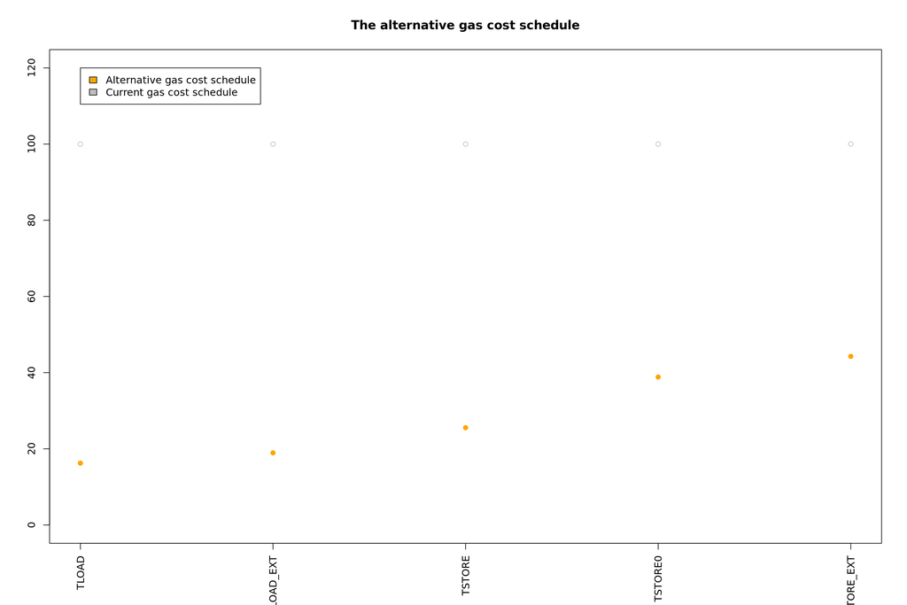

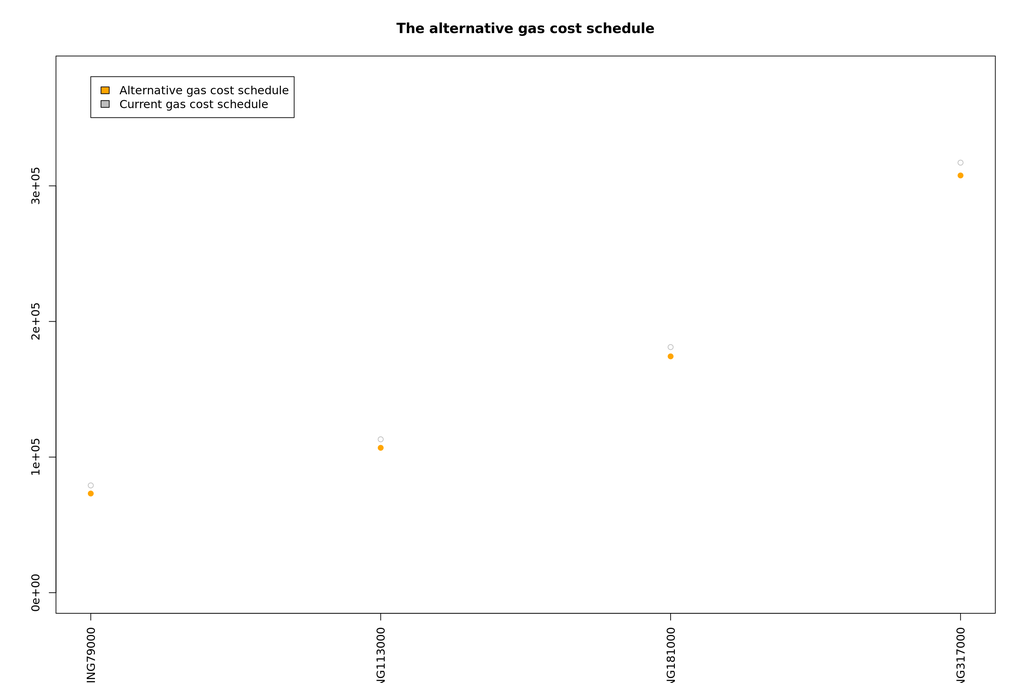

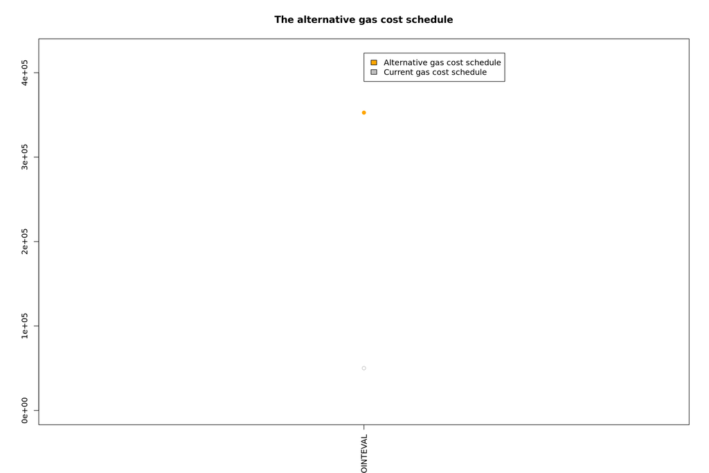

```r
for (g in 0:max_groups) {
  groups_opcode <- current_gas_cost[which(current_gas_cost$groups == g), "opcode"]
  if (length(groups_opcode) == 0) {
    next
  }
  grups_gas_schedule_comparison <- gas_schedule_comparison[which(gas_schedule_comparison$opcode %in% groups_opcode), c("opcode", "constant_current_gas", "alternative_gas")]
  if (nrow(grups_gas_schedule_comparison) == 0) {
    next
  }
  maximum_gas_cost = max(grups_gas_schedule_comparison[, c("constant_current_gas", "alternative_gas")], na.rm=TRUE)

  plot(grups_gas_schedule_comparison$constant_current_gas, col='grey', xaxt='n', ylim=c(0,maximum_gas_cost * 1.2), xlab="", ylab="")
  axis(1, at=1:nrow(grups_gas_schedule_comparison), labels=grups_gas_schedule_comparison$opcode, las=2)
  points(grups_gas_schedule_comparison$alternative_gas, col='orange', bg='orange', xaxt='n', pch=21)
  title(main="The alternative gas cost schedule")
  legend(1, maximum_gas_cost * 1.2, c("Alternative gas cost schedule", "Current gas cost schedule"), fill=c('orange', 'grey'), cex=1)
}
```